# DATA 599 - Survival Analysis HW5 - Charles Hanks

Due: February 24, 2023

# DATASET: pharmacoSmoking-asaur.txt

Leveraged from the Applied Survival Analysis Using R book, this data is from a randomized trial of triple therapy vs. patch for smoking cessation. Variables ttr and relapse are time to relapse (days) and whether or not a relapse occurred, respectively (1=relapse occurred, 0=no relapsed occurred.)

Please read in the dataset and do the following:

## A

Plot KM survival curves for each treatment group. Make sure your plot has reference lines for the median.

```r
#readin' 'n' wranglin'

ds = read_csv('pharmacoSmoking-asaur.txt')
head(ds)
```

```
## # A tibble: 6 × 14
##      id   ttr relapse grp       age gender race  emplo…¹ years…² level…³ ageGr…⁴
##   <dbl> <dbl>   <dbl> <chr>   <dbl> <chr>  <chr> <chr>     <dbl> <chr>   <chr>
## 1    21   182       0 patchO…    36 Male   white ft           26 heavy   21-49
## 2   113    14       1 patchO…    41 Male   white other        27 heavy   21-49
## 3    39     5       1 combin…    25 Female white other        12 heavy   21-49
## 4    80    16       1 combin…    54 Male   white ft           39 heavy   50+
## 5    87     0       1 combin…    45 Male   white other        30 heavy   21-49
## 6    29   182       0 combin…    43 Male   hisp… ft           30 heavy   21-49
## # … with 3 more variables: ageGroup4 <chr>, priorAttempts <dbl>,
## #   longestNoSmoke <dbl>, and abbreviated variable names ¹employment,
## #   ²yearsSmoking, ³levelSmoking, ⁴ageGroup2
```

```r
ds = ds %>%
  rename(sex = gender) %>%
  mutate(grp = factor(grp),
         sex = factor(sex))

 ds = ds %>%
    mutate(left= ifelse(ttr == 0,ttr+.001,ttr),
           right= ifelse(relapse == 1,left, NA)) %>%
  dplyr::select(id, ttr, relapse, age, grp,sex, left, right)

survObject=Surv(ds$left,ds$right,type="interval2")

#plottin'

km.smoking = survfit(survObject~ds$grp)

summary(km.smoking)
```

```
## Call: survfit(formula = survObject ~ ds$grp)
##
##                 ds$grp=combination
##     time n.risk n.event survival std.err lower 95% CI upper 95% CI
##    0.001   62.0    4.11    0.934  0.0292        0.875        0.997
##    2.000   57.9    3.08    0.884  0.0355        0.809        0.966
##    4.000   54.8    1.03    0.867  0.0369        0.788        0.955
##    5.000   53.8    2.05    0.834  0.0389        0.748        0.931
##    8.000   51.7    2.05    0.801  0.0402        0.709        0.906
##   10.000   49.7    1.03    0.785  0.0405        0.690        0.893
##   12.000   48.6    1.03    0.768  0.0407        0.671        0.879
##   14.000   47.6    1.03    0.752  0.0408        0.652        0.866
##   15.000   46.6    2.05    0.718  0.0406        0.616        0.838
##   16.000   44.5    1.03    0.702  0.0404        0.598        0.824
##   20.000   43.5    1.03    0.685  0.0400        0.580        0.810
##   21.000   42.5    1.03    0.669  0.0396        0.562        0.795
##   30.000   41.5    2.05    0.636  0.0385        0.527        0.766
##   42.000   39.4    1.03    0.619  0.0378        0.510        0.751
##   50.000   38.4    1.03    0.602  0.0371        0.493        0.736
##   56.000   37.4    2.05    0.569  0.0355        0.459        0.706
##   60.000   35.3    2.05    0.536  0.0337        0.426        0.675
##   63.000   33.2    2.05    0.503  0.0317        0.394        0.643
##   65.000   31.2    1.03    0.486  0.0307        0.377        0.627
##   75.000   30.2    1.03    0.470  0.0296        0.361        0.611
##  110.000   29.1    1.03    0.453  0.0285        0.346        0.595
##  140.000   28.1    3.08    0.404  0.0250        0.299        0.545
##  170.000   25.0    1.03    0.387  0.0238        0.283        0.529
##
##                 ds$grp=patchOnly
##     time n.risk n.event survival std.err lower 95% CI upper 95% CI
##    0.001   65.0    8.15    0.875 0.03565        0.798        0.958
##    1.000   56.8    5.10    0.796 0.03947        0.705        0.899
##    2.000   51.8    3.06    0.749 0.03996        0.652        0.861
##    3.000   48.7    1.02    0.733 0.03990        0.634        0.848
##    4.000   47.7    2.04    0.702 0.03951        0.600        0.822
##    6.000   45.6    1.02    0.686 0.03919        0.583        0.808
##    7.000   44.6    1.02    0.671 0.03879        0.566        0.794
##    8.000   43.6    1.02    0.655 0.03832        0.550        0.780
##   12.000   42.6    1.02    0.639 0.03778        0.533        0.766
##   14.000   41.6    6.12    0.545 0.03343        0.437        0.680
##   15.000   35.4    2.04    0.514 0.03163        0.406        0.650
##   21.000   33.4    1.02    0.498 0.03068        0.391        0.635
##   25.000   32.4    1.02    0.483 0.02970        0.376        0.620
##   28.000   31.4    3.06    0.436 0.02660        0.331        0.573
##   30.000   28.3    1.02    0.420 0.02553        0.316        0.558
##   40.000   27.3    1.02    0.404 0.02444        0.301        0.542
##   45.000   26.3    1.02    0.388 0.02334        0.287        0.526
##   49.000   25.3    1.02    0.373 0.02222        0.272        0.510
##   56.000   24.2    3.06    0.326 0.01883        0.230        0.461
##   77.000   21.2    2.04    0.294 0.01656        0.202        0.428
##   80.000   19.1    1.02    0.279 0.01543        0.189        0.411
##   84.000   18.1    1.02    0.263 0.01430        0.175        0.394
##  100.000   17.1    1.02    0.247 0.01318        0.162        0.377
##  105.000   16.1    1.02    0.232 0.01208        0.149        0.360
##  140.000   15.1    1.02    0.216 0.01099        0.136        0.343
##  155.000   14.0    1.02    0.200 0.00992        0.123        0.325
##  170.000   13.0    1.02    0.185 0.00887        0.111        0.307
```

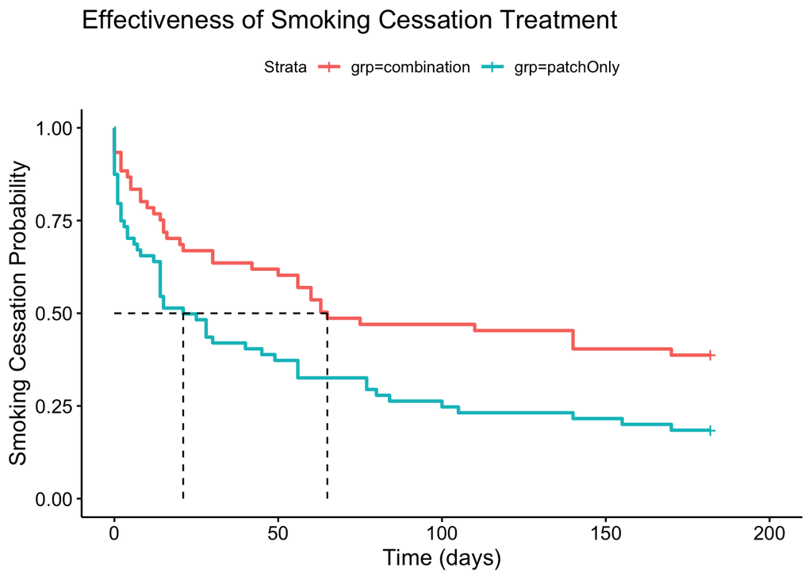

```r
ggsurvplot(fit = km.smoking, data = ds, risk.table = F, conf.int = F, surv.median.line = "hv" ) +
  labs(title = "Effectiveness of Smoking Cessation Treatment",
       x = "Time (days)",
       y = "Smoking Cessation Probability")
```

## B

Plot KM survival curves for each treatment group, stratifying by sex. Use linetype=“strata” to create separate curves for each stratum. Make sure your plot has reference lines for the median.

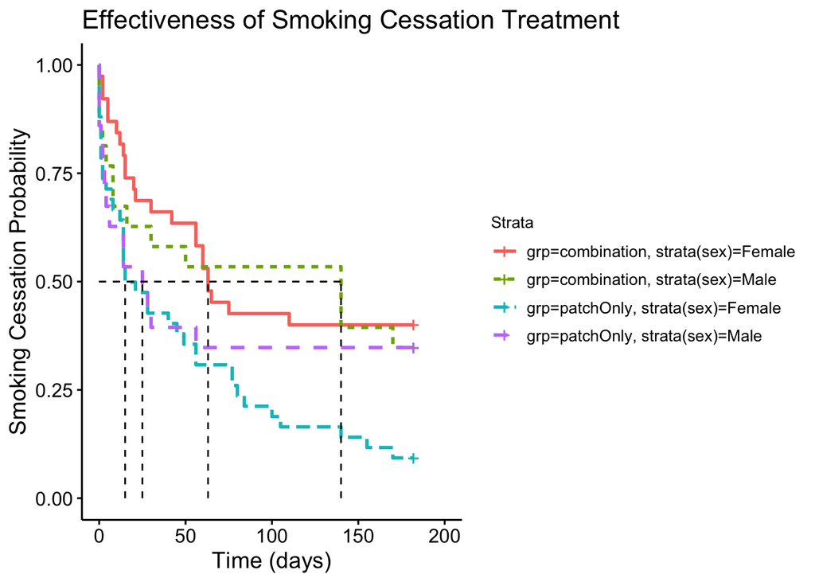

```r
km.smoking_strata.sex = survfit(survObject~ds$grp + strata(ds$sex))

ggsurvplot(fit = km.smoking_strata.sex, data = ds, risk.table = F, conf.int = F, linetype = "strata", surv.median.line = "hv", legend = "right" )  +
  labs(title = "Effectiveness of Smoking Cessation Treatment",
       x = "Time (days)",
       y = "Smoking Cessation Probability")
```

```r
#spaghetti
```

## C

For each treatment, does your plot suggest a difference in survival times between males and females? Explain.

*ANSWER:* Yes, based on the survival curves above, it appears that female patients with patch and combination treatments both have a lower survival probability of quitting smoking than the male patient with patch and combination treatment. The plot shows that the median time to relapse for females is lower than for males undergoing both treatment types.

## D

Fit a Weibull regression model for time to relapse as a function of age, sex, and the treatment. Name your model “myMod”.

```r
myMod = survreg(survObject~ds$age + ds$sex +ds$grp, dist = "weibull")
summary(myMod)
```

```
##
## Call:
## survreg(formula = survObject ~ ds$age + ds$sex + ds$grp, dist = "weibull")
##                   Value Std. Error     z      p
## (Intercept)      2.5103     1.3008  1.93  0.054
## ds$age           0.0577     0.0260  2.22  0.026
## ds$sexMale       0.3116     0.6166  0.51  0.613
## ds$grppatchOnly -1.4330     0.5813 -2.46  0.014
## Log(scale)       0.9766     0.0951 10.27 <2e-16
##
## Scale= 2.66
##
## Weibull distribution
## Loglik(model)= -415.2   Loglik(intercept only)= -421.8
##  Chisq= 13.34 on 3 degrees of freedom, p= 0.004
## Number of Newton-Raphson Iterations: 6
## n= 125
```

## E

Create residual diagnostic plots for `myMod`. (You should have 3 plots–one for each x.) Is your model valid? Why or why not?

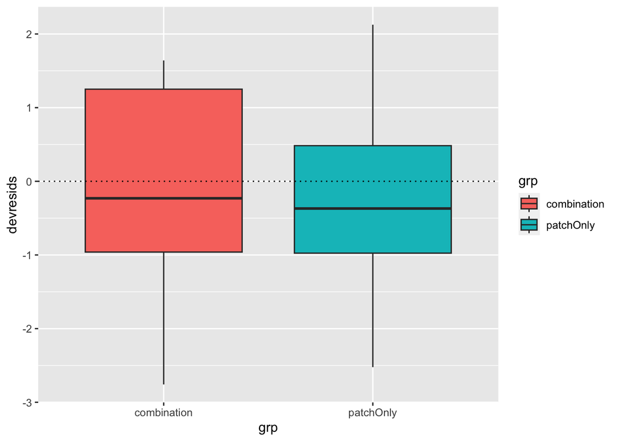

```r
# plot 1: x = grp (treatment type)
devresids=residuals(myMod,type="deviance")

ds %>% mutate(devresids=devresids) %>% ggplot(aes(y=devresids,x=grp,fill=grp)) +
geom_boxplot() + geom_hline(yintercept = 0,linetype="dotted")
```

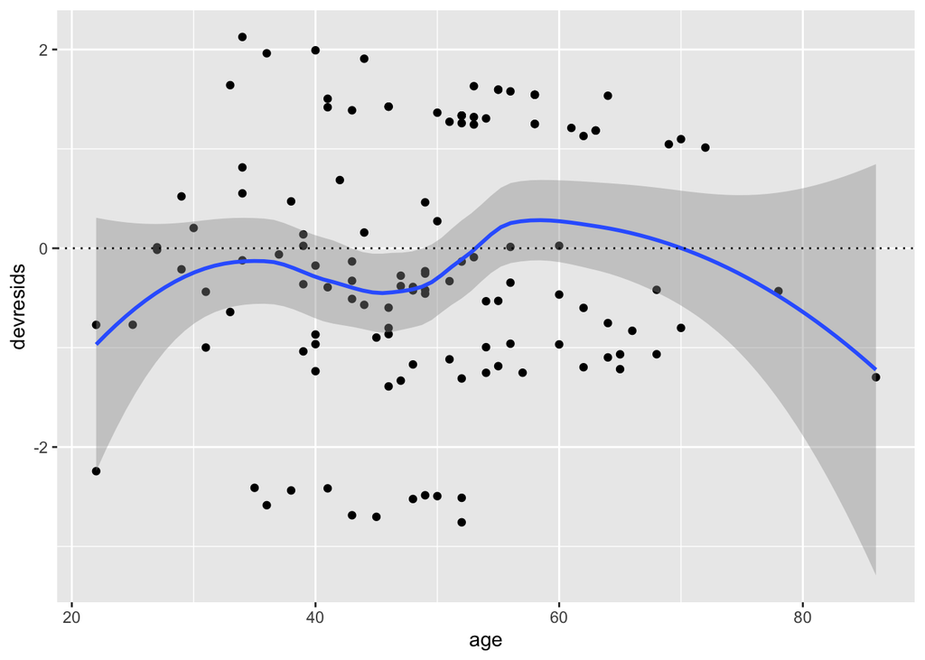

```r
# plot 2: x = age
tibble(resids=devresids,age=ds$age) %>%
  ggplot(aes(x=age,y=devresids)) + geom_point() +
  geom_smooth(method="loess") + geom_hline(yintercept=0,linetype="dotted")
```

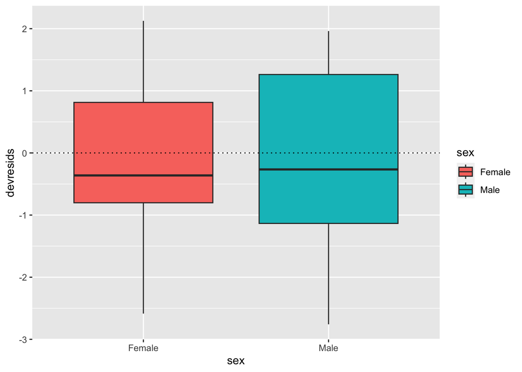

```r
#plot 3 x = sex
ds %>% ggplot(aes(y = devresids, x = sex, fill = sex)) +
  geom_boxplot() + geom_hline(yintercept = 0, linetype = "dotted")
```

*ANSWER:* The deviance residual plot for age is concerning. While the residuals are roughly centered around the 0 axis, the loess curve is parabolic, which means there is non-constant variance among the residuals. There may be another variable not accounted for in our model.

## F

What are the alpha and beta parameters for a 25-year old male smoker who is being given the patch only?

mu = intercept + b_1*x_1 + b_2*x_2 + b_3*x_3

```r
summary(myMod)
```

```
##
## Call:
## survreg(formula = survObject ~ ds$age + ds$sex + ds$grp, dist = "weibull")
##                   Value Std. Error     z      p
## (Intercept)      2.5103     1.3008  1.93  0.054
## ds$age           0.0577     0.0260  2.22  0.026
## ds$sexMale       0.3116     0.6166  0.51  0.613
## ds$grppatchOnly -1.4330     0.5813 -2.46  0.014
## Log(scale)       0.9766     0.0951 10.27 <2e-16
##
## Scale= 2.66
##
## Weibull distribution
## Loglik(model)= -415.2   Loglik(intercept only)= -421.8
##  Chisq= 13.34 on 3 degrees of freedom, p= 0.004
## Number of Newton-Raphson Iterations: 6
## n= 125
```

```r
intercept = 2.5103
b_1 = 0.0577
b_2 = 0.3116
b_3 = -1.4330

mu = intercept + b_1*25 + b_2*1 + b_3*1

alpha = exp(mu)
alpha
```

```
## [1] 16.9692
```

```r
beta = 1/myMod$scale
```

*ANSWER:* alpha = 16.969, beta = 0.377

## G

Based on your answer in part F, what is the probability of a 25-year old male smoker who is being given the patch only relapsing by 60 days?

```r
pweibull(60, beta, alpha, lower.tail = TRUE)
```

```
## [1] 0.799914
```

*ANSWER:* The probability of a 25 year old male smoker who is given only the patch relapsing within 60 days is .80.